# Game sales analysis

### Author: Xia Cui

### Introduction

This report presents the analysis of the video games sales data from the online store Ice, spanning over 30 years from 1980 to 2016.

The dataset contains information of the games' platform and genre, the year they were released, their sales in three regions, North America, Europe, and Japan, expert and user review scores, and their ESRB (Entertainment Software Rating Board) rating.

The goal of the analysis is to identify patterns that determine whether a game succeeds or not, which will then allow the store owners to spot potential sales winners and plan advertising campaigns.

The report first shows the steps followed to prepare the data for analysis, then the exploratory data analysis addressing key questions including:

- the pattern in releasing games;
- how sales varied across platforms and how that changes over time;
- how user and professional reviews affect sales;
- how sales of same games varied across platforms; and
- how genres affected sales.

Following the above analysis, a user profile will be created for each of the three regions. We will take a look at the top five platforms and genres for each region, and how ESRB ratings affect sales in individual regions.

Finally, we will test 2 hypotheses:

- average user ratings of the Xbox One and PC platforms are the same.
- average user ratings for the Action and Sports genres are different.

What follows is the table of content for easy navigation of the report.

### Table of content

#### Part 1: Data importing

#### Part 2: Data preprocessing

#### Part 3: Data transformation

#### Part 4: Exploratory data analysis

#### Part 5: Games and regions

#### Part 6: Hypothesis testing

#### Part 7: Findings and conclusions

```python
import pandas as pd
import numpy as np
import math
from matplotlib import pyplot as plt
from scipy import stats as st
from IPython.display import display
import seaborn as sns
import warnings
warnings.filterwarnings("ignore")
%matplotlib inline
```

### Part 1: Data importing

```python
games = pd.read_csv("https://code.s3.yandex.net/datasets/games.csv")
games.head()
```

|  | Name | Platform | Year_of_Release | Genre | NA_sales | EU_sales | JP_sales | Other_sales | Critic_Score | User_Score | Rating |
| --- | --- | --- | --- | --- | --- | --- | --- | --- | --- | --- | --- |
| 0 | Wii Sports | Wii | 2006.0 | Sports | 41.36 | 28.96 | 3.77 | 8.45 | 76.0 | 8 | E |
| 1 | Super Mario Bros. | NES | 1985.0 | Platform | 29.08 | 3.58 | 6.81 | 0.77 | NaN | NaN | NaN |
| 2 | Mario Kart Wii | Wii | 2008.0 | Racing | 15.68 | 12.76 | 3.79 | 3.29 | 82.0 | 8.3 | E |
| 3 | Wii Sports Resort | Wii | 2009.0 | Sports | 15.61 | 10.93 | 3.28 | 2.95 | 80.0 | 8 | E |
| 4 | Pokemon Red/Pokemon Blue | GB | 1996.0 | Role-Playing | 11.27 | 8.89 | 10.22 | 1.00 | NaN | NaN | NaN |

Let's take a look at the general information of the dataset.

```python
games.info()
```

```
<class 'pandas.core.frame.DataFrame'>
RangeIndex: 16715 entries, 0 to 16714
Data columns (total 11 columns):
 #   Column           Non-Null Count  Dtype
---  ------           --------------  -----
 0   Name             16713 non-null  object
 1   Platform         16715 non-null  object
 2   Year_of_Release  16446 non-null  float64
 3   Genre            16713 non-null  object
 4   NA_sales         16715 non-null  float64
 5   EU_sales         16715 non-null  float64
 6   JP_sales         16715 non-null  float64
 7   Other_sales      16715 non-null  float64
 8   Critic_Score     8137 non-null   float64
 9   User_Score       10014 non-null  object
 10  Rating           9949 non-null   object
dtypes: float64(6), object(5)
memory usage: 1.4+ MB
```

For columns that have 'object' datatypes, let's check their values, and unnecessary white spaces.

**Checking the string columns**

```python
games['Platform'].unique()
```

```
array(['Wii', 'NES', 'GB', 'DS', 'X360', 'PS3', 'PS2', 'SNES', 'GBA',
       'PS4', '3DS', 'N64', 'PS', 'XB', 'PC', '2600', 'PSP', 'XOne',
       'WiiU', 'GC', 'GEN', 'DC', 'PSV', 'SAT', 'SCD', 'WS', 'NG', 'TG16',
       '3DO', 'GG', 'PCFX'], dtype=object)
```

```python
games['Genre'].unique()
```

```
array(['Sports', 'Platform', 'Racing', 'Role-Playing', 'Puzzle', 'Misc',
       'Shooter', 'Simulation', 'Action', 'Fighting', 'Adventure',
       'Strategy', nan], dtype=object)
```

```python
games['Rating'].unique()
```

```
array(['E', nan, 'M', 'T', 'E10+', 'K-A', 'AO', 'EC', 'RP'], dtype=object)
```

The above three columns look fine. Now let's check the *Name* column.

```python
games['Name'].str.isspace().sum()
```

```
0
```

```python
games['Name'].str.startswith(" ").sum()
```

```
6
```

```python
games['Name'].str.endswith(" ").sum()
```

```
23
```

There are six that start with empty space, and 23 that end with empty space. This will need to be addressed in the data preprocessing later.

Among the columns, *User_score* is supposed to be float, but shown as object. Let's take a closer look.

```python
games['User_Score'].value_counts()
```

```
tbd    2424
7.8     324
8       290
8.2     282
8.3     254
       ...
1.1       2
0.6       2
1.9       2
9.7       1
0         1
Name: User_Score, Length: 96, dtype: int64
```

Now we know the reason: there is a tdb value among the numbers. This refers to 'to be determined'. We will need to address this matter later as well.

**Checking the numeric columns**

After checking on the columns of object datatype, let's look at the numeric columns.

```python
games.describe()
```

|  | Year_of_Release | NA_sales | EU_sales | JP_sales | Other_sales | Critic_Score |
| --- | --- | --- | --- | --- | --- | --- |
| count | 16446.000000 | 16715.000000 | 16715.000000 | 16715.000000 | 16715.000000 | 8137.000000 |
| mean | 2006.484616 | 0.263377 | 0.145060 | 0.077617 | 0.047342 | 68.967679 |
| std | 5.877050 | 0.813604 | 0.503339 | 0.308853 | 0.186731 | 13.938165 |
| min | 1980.000000 | 0.000000 | 0.000000 | 0.000000 | 0.000000 | 13.000000 |
| 25% | 2003.000000 | 0.000000 | 0.000000 | 0.000000 | 0.000000 | 60.000000 |
| 50% | 2007.000000 | 0.080000 | 0.020000 | 0.000000 | 0.010000 | 71.000000 |
| 75% | 2010.000000 | 0.240000 | 0.110000 | 0.040000 | 0.030000 | 79.000000 |
| max | 2016.000000 | 41.360000 | 28.960000 | 10.220000 | 10.570000 | 98.000000 |

A quick look at the summary statitics of the numeric columns shows that the sales values tend to be heavily right skewed, containing outliers on the high value end. We will keep this in mind for now.

**Checking null values**

```python
games.isnull().sum()/len(games)
```

```
Name               0.000120
Platform           0.000000
Year_of_Release    0.016093
Genre              0.000120
NA_sales           0.000000
EU_sales           0.000000
JP_sales           0.000000
Other_sales        0.000000
Critic_Score       0.513192
User_Score         0.400897
Rating             0.404786
dtype: float64
```

As shown, columns that are most impacted by null values are Critic_Score, User_Score, and Rating. We will address this in the next section.

### Part 1 Summary

A closer examination of the dataset reveals the following issues to be addressed:

- there are missing values in 6 columns, and the percentage for 3 of them is quite high,around 50%.
- column names are a mix of upper and lower cases, so are the values in the dataset. They will need to be changed to all lower case.
- User_Score has *tbd* in its values and therefore is shown as 'object' datatype. We will change the column to be float datatype.
- there are white spaces at the start and end of the values in column 'Name'. We will get rid out these.

In the section that follows, we will address the above issues.

### Part 2: Data preprocessing

**2.1 Changing the columns and values to lower case and removing white space**

```python
games.columns = games.columns.str.lower()
```

```python
games['genre'] = games['genre'].str.lower()
games['platform'] = games['platform'].str.lower()
games['name'] = games['name'].str.lower()
```

```python
games['name'] = games['name'].str.strip()
```

Now let's check.

```python
games.columns
```

```
Index(['name', 'platform', 'year_of_release', 'genre', 'na_sales', 'eu_sales',
       'jp_sales', 'other_sales', 'critic_score', 'user_score', 'rating'],
      dtype='object')
```

```python
games['name'].str.startswith(" ").sum()
```

```
0
```

```python
games['name'].str.endswith(" ").sum()
```

```
0
```

**2.2 Resolving missing values**

```python
games.isna().sum()
```

```
name                  2
platform              0
year_of_release     269
genre                 2
na_sales              0
eu_sales              0
jp_sales              0
other_sales           0
critic_score       8578
user_score         6701
rating             6766
dtype: int64
```

**Missing values in 'name'column**

Let's take a look at the na values in name.

```python
games[games['name'].isna()]
```

|  | name | platform | year_of_release | genre | na_sales | eu_sales | jp_sales | other_sales | critic_score | user_score | rating |
| --- | --- | --- | --- | --- | --- | --- | --- | --- | --- | --- | --- |
| 659 | NaN | gen | 1993.0 | NaN | 1.78 | 0.53 | 0.00 | 0.08 | NaN | NaN | NaN |
| 14244 | NaN | gen | 1993.0 | NaN | 0.00 | 0.00 | 0.03 | 0.00 | NaN | NaN | NaN |

The entries that have NaN values in name also happen to have NaN in genre. Let's see if we can find information about game name from 'year_of_release" and 'platform" columns.

```python
games[(games['year_of_release'] == 1993) & (games['platform'] == "gen")].head()
```

|  | name | platform | year_of_release | genre | na_sales | eu_sales | jp_sales | other_sales | critic_score | user_score | rating |
| --- | --- | --- | --- | --- | --- | --- | --- | --- | --- | --- | --- |
| 659 | NaN | gen | 1993.0 | NaN | 1.78 | 0.53 | 0.00 | 0.08 | NaN | NaN | NaN |
| 7885 | shining force ii | gen | 1993.0 | strategy | 0.00 | 0.00 | 0.19 | 0.00 | NaN | NaN | NaN |
| 8893 | super street fighter ii | gen | 1993.0 | fighting | 0.00 | 0.00 | 0.15 | 0.00 | NaN | NaN | NaN |
| 11986 | ecco: the tides of time | gen | 1993.0 | adventure | 0.00 | 0.00 | 0.07 | 0.00 | NaN | NaN | NaN |
| 12098 | street fighter ii': special champion edition (... | gen | 1993.0 | action | 0.00 | 0.00 | 0.07 | 0.00 | NaN | NaN | NaN |

It seems that information of the year and platform doesn't help with filling the na values in name or genre. These two rows will be dropped.

```python
games = games[games['name'].notna()]
```

```python
games['name'].isna().sum()
```

```
0
```

```python
games[games['year_of_release'].isna()].head()
```

|  | name | platform | year_of_release | genre | na_sales | eu_sales | jp_sales | other_sales | critic_score | user_score | rating |
| --- | --- | --- | --- | --- | --- | --- | --- | --- | --- | --- | --- |
| 183 | madden nfl 2004 | ps2 | NaN | sports | 4.26 | 0.26 | 0.01 | 0.71 | 94.0 | 8.5 | E |
| 377 | fifa soccer 2004 | ps2 | NaN | sports | 0.59 | 2.36 | 0.04 | 0.51 | 84.0 | 6.4 | E |
| 456 | lego batman: the videogame | wii | NaN | action | 1.80 | 0.97 | 0.00 | 0.29 | 74.0 | 7.9 | E10+ |
| 475 | wwe smackdown vs. raw 2006 | ps2 | NaN | fighting | 1.57 | 1.02 | 0.00 | 0.41 | NaN | NaN | NaN |
| 609 | space invaders | 2600 | NaN | shooter | 2.36 | 0.14 | 0.00 | 0.03 | NaN | NaN | NaN |

**Missing values in 'year_of_release' column**

```python
games['year_of_release'].isna().sum()
```

```
269
```

```python
games[games['year_of_release'].isna()].head()
```

|  | name | platform | year_of_release | genre | na_sales | eu_sales | jp_sales | other_sales | critic_score | user_score | rating |
| --- | --- | --- | --- | --- | --- | --- | --- | --- | --- | --- | --- |
| 183 | madden nfl 2004 | ps2 | NaN | sports | 4.26 | 0.26 | 0.01 | 0.71 | 94.0 | 8.5 | E |
| 377 | fifa soccer 2004 | ps2 | NaN | sports | 0.59 | 2.36 | 0.04 | 0.51 | 84.0 | 6.4 | E |
| 456 | lego batman: the videogame | wii | NaN | action | 1.80 | 0.97 | 0.00 | 0.29 | 74.0 | 7.9 | E10+ |
| 475 | wwe smackdown vs. raw 2006 | ps2 | NaN | fighting | 1.57 | 1.02 | 0.00 | 0.41 | NaN | NaN | NaN |
| 609 | space invaders | 2600 | NaN | shooter | 2.36 | 0.14 | 0.00 | 0.03 | NaN | NaN | NaN |

We will take a look at the first game in the list above to see if we can get some information about the release year from other columns.

```python
games[games['name'] == "madden nfl 2004"]
```

|  | name | platform | year_of_release | genre | na_sales | eu_sales | jp_sales | other_sales | critic_score | user_score | rating |
| --- | --- | --- | --- | --- | --- | --- | --- | --- | --- | --- | --- |
| 183 | madden nfl 2004 | ps2 | NaN | sports | 4.26 | 0.26 | 0.01 | 0.71 | 94.0 | 8.5 | E |
| 1881 | madden nfl 2004 | xb | 2003.0 | sports | 1.02 | 0.02 | 0.00 | 0.05 | 92.0 | 8.3 | E |
| 3889 | madden nfl 2004 | gc | 2003.0 | sports | 0.40 | 0.10 | 0.00 | 0.01 | 94.0 | 7.7 | E |
| 5708 | madden nfl 2004 | gba | 2003.0 | sports | 0.22 | 0.08 | 0.00 | 0.01 | 70.0 | 6.6 | E |

It seems that games with the same name were released in the same year. Therefore we can fill the missing years using that of the games having the same name. However, it's very likely that some games with missing release year only appear once in the dataframe.

```python
games['year_of_release'] = games.groupby('name')['year_of_release'].transform(
    lambda x: x.fillna(x.mode()[0] if not x.mode().empty else x))
```

```python
games['year_of_release'].isna().sum()
```

```
146
```

The above shows that we still have 146 missing years because these games appear only once and therefore doesn't have any release year information. This represents less than 1% of the total data. Because we need 'year_of_release' later when we look at the trend in game polularity, we will drop these 146 rows from the dataset.

```python
games = games[games['year_of_release'].notna()]
```

```python
games.isna().sum()
```

```
name                  0
platform              0
year_of_release       0
genre                 0
na_sales              0
eu_sales              0
jp_sales              0
other_sales           0
critic_score       8492
user_score         6633
rating             6699
dtype: int64
```

**Missing values in the rest three columns**

Before we move on to deal with the missing values in the last three columns, let's change the data type of the 'user_score' column.

```python
games['user_score'].dtypes
```

```
dtype('O')
```

```python
games[games['user_score'] == 'tbd'].head()
```

|  | name | platform | year_of_release | genre | na_sales | eu_sales | jp_sales | other_sales | critic_score | user_score | rating |
| --- | --- | --- | --- | --- | --- | --- | --- | --- | --- | --- | --- |
| 119 | zumba fitness | wii | 2010.0 | sports | 3.45 | 2.59 | 0.0 | 0.66 | NaN | tbd | E |
| 301 | namco museum: 50th anniversary | ps2 | 2005.0 | misc | 2.08 | 1.35 | 0.0 | 0.54 | 61.0 | tbd | E10+ |
| 520 | zumba fitness 2 | wii | 2011.0 | sports | 1.51 | 1.03 | 0.0 | 0.27 | NaN | tbd | T |
| 645 | udraw studio | wii | 2010.0 | misc | 1.65 | 0.57 | 0.0 | 0.20 | 71.0 | tbd | E |
| 718 | just dance kids | wii | 2010.0 | misc | 1.52 | 0.54 | 0.0 | 0.18 | NaN | tbd | E |

It doesn't look like that we can obtain useful information from other columns to fill the tbd value. Therefore, we will change the column to numeric data type and use 'coerce' for the errors parameter. This will force the tbd values to NaN.

```python
games['user_score'] = pd.to_numeric(games['user_score'], errors = 'coerce')
```

```python
games['user_score'].dtypes
```

```
dtype('float64')
```

While we are here, let's also change the 'year_of_release' to integer datatype to get rid of the 0 after the decimal point.

```python
games['year_of_release'] = games['year_of_release'].astype('int')
```

```python
games['user_score'].isna().sum()
```

```
9027
```

Now 'user_score' column has more missing values.

A glimpse of the first few rows with missing 'user_score' values shows the possibility that rows that miss 'user_score' might also miss the 'critic_score' and 'rating' values. Let's check.

```python
len(games[(games['critic_score'].isna()) & (games['user_score'].isna()) &
          (games['rating'].isna())])
```

```
6601
```

Indeed, there are 6601 rows that have missing values in all three columns. It's a rather significant number because it represents almost 40% of the total dataset.

It is not clear why this is the case. In reality, it might be possible to restore this information if we could check with the team who provided the data, or this information simply doesn't exist. In either case, given majority of our analysis focuses on sales figures, we can leave these missing values as they are.

The crictic_score and user_score columns are float type showing numbers. Therefore we can't replace missing values with '0' because this will distort the data.

For the rating column, we can replace missing values with 'undefined'. Let's go ahead and do it.

```python
games['rating'] = games['rating'].fillna('undefined')
```

```python
games.isna().sum()
```

```
name                  0
platform              0
year_of_release       0
genre                 0
na_sales              0
eu_sales              0
jp_sales              0
other_sales           0
critic_score       8492
user_score         9027
rating                0
dtype: int64
```

In one of the analysis tasks later, we will examine the correlation bewteen sales and expert and user reviews. So we will need to bear in mind that there are still missing values in these two columns.

### Part 2 summary

In this section, we've changed the column names and string values in the dataset all in lower case, removed the white space at the beginning and end of the 'name' column, filled up the missing values in the dataset to the best we can, and changed the columns to their correct datatype. Before we proceed to exploratory data analysis, we will add a 'total_sales' column next.

### Part 3: Data transformation

We will need a 'total_sales' column when we later look at the sales across platform. Let's do that now.

```python
games['total_sales'] = games['na_sales'] + games['eu_sales'] + games[
    'jp_sales'] + games['other_sales']
```

```python
games.head()
```

|  | name | platform | year_of_release | genre | na_sales | eu_sales | jp_sales | other_sales | critic_score | user_score | rating | total_sales |
| --- | --- | --- | --- | --- | --- | --- | --- | --- | --- | --- | --- | --- |
| 0 | wii sports | wii | 2006 | sports | 41.36 | 28.96 | 3.77 | 8.45 | 76.0 | 8.0 | E | 82.54 |
| 1 | super mario bros. | nes | 1985 | platform | 29.08 | 3.58 | 6.81 | 0.77 | NaN | NaN | undefined | 40.24 |
| 2 | mario kart wii | wii | 2008 | racing | 15.68 | 12.76 | 3.79 | 3.29 | 82.0 | 8.3 | E | 35.52 |
| 3 | wii sports resort | wii | 2009 | sports | 15.61 | 10.93 | 3.28 | 2.95 | 80.0 | 8.0 | E | 32.77 |
| 4 | pokemon red/pokemon blue | gb | 1996 | role-playing | 11.27 | 8.89 | 10.22 | 1.00 | NaN | NaN | undefined | 31.38 |

Now the dataset is ready to be analysed!

### Part 4: Exploratory data analysis

**4.1 Games released by year**

First, let's find out if there is any pattern in game release year by year.

```python
len(games['year_of_release'].unique())
```

```
37
```

```python
games.groupby('year_of_release')['name'].count().sort_values(ascending=False).head()
```

```
year_of_release
2008    1441
2009    1430
2010    1270
2007    1202
2011    1153
Name: name, dtype: int64
```

As shown above, the dataset contains games released over 37 years, and the top five years for game release are 2008, 2009, 2010, 2007, and 2011.

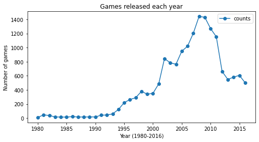

```python
games['year_of_release'].value_counts().rename_axis(
    'year_of_release').reset_index(name='counts').sort_values(
    'year_of_release').plot(x="year_of_release", y='counts', style = 'o-', figsize = (8,4))
plt.title('Games released each year')
plt.ylabel("Number of games")
plt.xlabel("Year (1980-2016)")
plt.show()
```

It's very interesting to see that the number of games released remained very low until 1993, after which we see overall a steady increase, despite some fluctuation around 2000 and 2005. The number reached its peak at 2008 and 2009, followed by a quite drastic decline in the years that follow. By the time it was 2015, the number has dropped to less than half of its peak.

Without any further information, we might conclude that video games were at their peak in terms of game release between 2007 to 2011. It could be that games in recently years are more complex and take longer time to develop. For the purpose of this report, we will leave it here.

**4.2 Sales across platforms**

```python
len(games['platform'].unique())
```

```
31
```

```python
games.groupby('platform')['total_sales'].sum().sort_values(ascending=False).head(6)
```

```
platform
ps2     1247.16
x360     966.61
ps3      935.19
wii      903.31
ds       804.28
ps       727.58
Name: total_sales, dtype: float64
```

There are a total of 31 platforms, and those that generated the highest total sales are above. Let's pick these 6 and take a look at how their sales might have changed over the years.

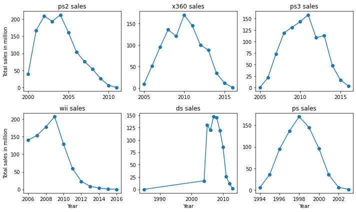

```python
fig, ((ax1, ax2, ax3), (ax4, ax5, ax6)) = plt.subplots(2, 3, figsize=(10, 6))

games[games['platform'] == "ps2"].groupby(
    'year_of_release')['total_sales'].sum().plot(style="o-", ax=ax1)
ax1.set_xlabel("")
ax1.set_ylabel("Total sales in million")
ax1.set_title("ps2 sales")
ax1.locator_params(integer=True)

games[games['platform'] == "x360"].groupby(
    'year_of_release')['total_sales'].sum().plot(style="o-", ax=ax2)
ax2.set_xlabel("")
ax2.set_title("x360 sales")
ax2.locator_params(integer=True)

games[games['platform'] == "ps3"].groupby(
    'year_of_release')['total_sales'].sum().plot(style="o-", ax=ax3)
ax3.set_xlabel("")
ax3.set_title("ps3 sales")
ax3.locator_params(integer=True)

games[games['platform'] == "wii"].groupby(
    'year_of_release')['total_sales'].sum().plot(style="o-", ax=ax4)
ax4.set_xlabel("Year")
ax4.set_ylabel("Total sales in million")
ax4.set_title("wii sales")
ax4.locator_params(integer=True)

games[games['platform'] == "ds"].groupby(
    'year_of_release')['total_sales'].sum().plot(style="o-", ax=ax5)
ax5.set_xlabel("Year")
ax5.set_title("ds sales")
ax5.locator_params(integer=True)

games[games['platform'] == "ps"].groupby(
    'year_of_release')['total_sales'].sum().plot(style="o-", ax=ax6)
ax6.set_xlabel("Year")
ax6.set_title("ps sales")
ax6.locator_params(integer=True)

plt.tight_layout()
```

Although sales of all the above 6 platforms dropped significantly in the end, 'ps2' and 'wii' in particular seem to have dropped to almost zero. Let's check.

```python
games[games['platform'] == "ps2"].groupby(
    'year_of_release')['total_sales'].sum().tail(1)
```

```
year_of_release
2011    0.45
Name: total_sales, dtype: float64
```

```python
games[games['platform'] == "wii"].groupby(
    'year_of_release')['total_sales'].sum().tail(1)
```

```
year_of_release
2016    0.18
Name: total_sales, dtype: float64
```

Based on the information above, it seems that a platform's lifespan is around 10 years between when it started to trend and when it started to disappear from the market. The popularity peaked after approximately 4 or 5 years.

For ps2, for example, its sales started to increase in 2000, reached its peak at 2004, and by 2011, its sales dropped to 0.45 million. There is not sales figure following that, which leads us to assume that it was out of the market.

For ds, although the games on this platform started to sell as early as 1985, the sales didn't pick up until 2004. It then quickly reached its sales peak in 2007 and 2008, followed by a drastic decline, dropping to 1.54 million in 2013.

It should also be noted though, the number of games released each year has been declining since 2010. This could potentially be partly blamed for the overall deseasing global sales.

Further more, it says in the data description that data in 2016 might not be complete. Incomplete yearly sales figure still taken as a year could be very misleading. To slice the data, we will still include the 2016 data but bear in mind that it's not complete.

It's also good to have a clear idea how old the platforms are, in case that is not clear from the sliced data. So let's save that information as well.

Let's go ahead and slice the 2012 to 2016 data.

**4.3 Slicing the data for further analysis**

```python
games_new = games[(games['year_of_release'] >= 2012)
                  & (games['year_of_release'] <= 2016)]
```

```python
games_new.shape
```

```
(2899, 12)
```

The new game dataset contains 2899 rows. Before we move on with further analysis, let's just quickly get from the old dataset information on which year the platforms included in the new dataset started.

```python
games_new['platform'].unique()
```

```
array(['ps3', 'x360', 'ps4', '3ds', 'ds', 'xone', 'wiiu', 'wii', 'pc',
       'psv', 'psp'], dtype=object)
```

```python
platform_list = [
    'ps3', 'x360', 'ps4', '3ds', 'ds', 'xone', 'wiiu', 'wii', 'pc', 'psv',
    'psp'
]
```

```python
year_list = []
for platform in platform_list:
    year = games[games['platform'] == platform]['year_of_release'].min()
    year_list.append(year)

year_list
```

```
[2005, 2005, 2013, 2000, 1985, 2013, 2012, 2006, 1985, 2011, 2004]
```

```python
platform_year = pd.DataFrame({
    "Platform": platform_list,
    "start_year": year_list
})
platform_year
```

|  | Platform | start_year |
| --- | --- | --- |
| 0 | ps3 | 2005 |
| 1 | x360 | 2005 |
| 2 | ps4 | 2013 |
| 3 | 3ds | 2000 |
| 4 | ds | 1985 |
| 5 | xone | 2013 |
| 6 | wiiu | 2012 |
| 7 | wii | 2006 |
| 8 | pc | 1985 |
| 9 | psv | 2011 |
| 10 | psp | 2004 |

**4.4 Top selling and potentially profitable platforms**

First, we will have a look at the total sales generated from each platform.

```python
games_new.groupby('platform')['total_sales'].sum().sort_values(ascending=False)
```

```
platform
ps4     314.14
ps3     289.71
x360    237.52
3ds     195.01
xone    159.32
wiiu     82.19
pc       63.51
psv      49.18
wii      36.60
ds       13.21
psp      11.69
Name: total_sales, dtype: float64
```

The top 5 selling platforms in the five years leading to 2016 ps4, ps3, x360, 3ds, and xone! However, they don't really tell which platforms might be on the decline already, and which ones might be on the rise. To obtain that information, let's plot the sales from each platform.

From previous plots, we already know ps3, x360, wii, ds have reached their peak and been declining ever since. So let's check out the other platforms in the plots below: ps4, 3ds, xone, pc, wiiu, psp, psv. Knowing the 2016 data is not complete, we will exclude the sales from 2016 for the plots below.

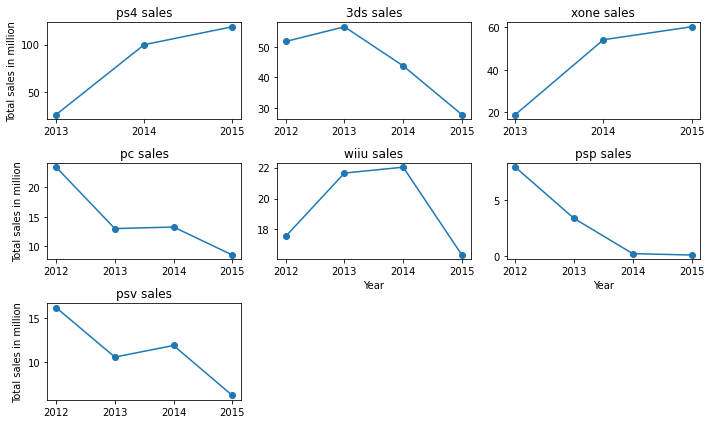

```python
fig, ((ax1, ax2, ax3), (ax4, ax5, ax6), (ax7, ax8, ax9)) = plt.subplots(3,
                                                       3,
                                                       figsize=(10, 6),
                                                       sharex=False)

games_new[(games_new['platform'] == "ps4")
          & (games_new['year_of_release'] != 2016)].groupby(
              'year_of_release')['total_sales'].sum().plot(style="o-", ax=ax1)
ax1.set_xlabel("")
ax1.set_ylabel("Total sales in million")
ax1.set_title("ps4 sales")
ax1.locator_params(integer=True)

games_new[(games_new['platform'] == "3ds")
          & (games_new['year_of_release'] != 2016)].groupby(
              'year_of_release')['total_sales'].sum().plot(style="o-", ax=ax2)
ax2.set_xlabel("")
ax2.set_title("3ds sales")
ax2.locator_params(integer=True)

games_new[(games_new['platform'] == "xone")
          & (games_new['year_of_release'] != 2016)].groupby(
              'year_of_release')['total_sales'].sum().plot(style="o-", ax=ax3)
ax3.set_xlabel("")
ax3.set_title("xone sales")
ax3.locator_params(integer=True)

games_new[(games_new['platform'] == "pc")
          & (games_new['year_of_release'] != 2016)].groupby(
              'year_of_release')['total_sales'].sum().plot(style="o-", ax=ax4)
ax4.set_xlabel("")
ax4.set_title("pc sales")
ax4.set_ylabel("Total sales in million")
ax4.locator_params(integer=True)

games_new[(games_new['platform'] == "wiiu")
          & (games_new['year_of_release'] != 2016)].groupby(
              'year_of_release')['total_sales'].sum().plot(style="o-", ax=ax5)
ax5.set_xlabel("Year")
ax5.set_title("wiiu sales")
ax5.locator_params(integer=True)

games_new[(games_new['platform'] == "psp")
          & (games_new['year_of_release'] != 2016)].groupby(
              'year_of_release')['total_sales'].sum().plot(style="o-", ax=ax6)
ax6.set_xlabel("Year")
ax6.set_title("psp sales")
ax6.locator_params(integer=True)

games_new[(games_new['platform'] == "psv")
          & (games_new['year_of_release'] != 2016)].groupby(
              'year_of_release')['total_sales'].sum().plot(style="o-", ax=ax7)
ax7.set_xlabel("")
ax7.set_title("psv sales")
ax7.set_ylabel("Total sales in million")
ax7.locator_params(integer=True)

fig.delaxes(ax8)
fig.delaxes(ax9)

plt.tight_layout()
```

```python
display(platform_year)
```

|  | Platform | start_year |
| --- | --- | --- |
| 0 | ps3 | 2005 |
| 1 | x360 | 2005 |
| 2 | ps4 | 2013 |
| 3 | 3ds | 2000 |
| 4 | ds | 1985 |
| 5 | xone | 2013 |
| 6 | wiiu | 2012 |
| 7 | wii | 2006 |
| 8 | pc | 1985 |
| 9 | psv | 2011 |
| 10 | psp | 2004 |

Given what we know so far about the life span of a platform, two platforms, **ps4** and **xone** , which started in 2013, are most likely on the rising trend in their popularity.

In contrast, psp, which started in 2004, seemed to have already reached its peak, similar to ps3, x360, wii, and ds, which we plotted earlier. pc platform too, which started as far back as in 1985, seemed to have reached its peak and was just hanging there for a bit.

**4.5 Global sales of games across all platforms**

First, let's take a look at the summary statistics of the game sales on all platforms.

```python
games_new.groupby('platform')['total_sales'].describe()
```

| platform | count | mean | std | min | 25% | 50% | 75% | max |
| --- | --- | --- | --- | --- | --- | --- | --- | --- |
| 3ds | 397.0 | 0.491209 | 1.385416 | 0.01 | 0.040 | 0.11 | 0.320 | 14.60 |
| ds | 32.0 | 0.412812 | 1.416559 | 0.01 | 0.020 | 0.05 | 0.195 | 8.06 |
| pc | 255.0 | 0.249059 | 0.490149 | 0.01 | 0.030 | 0.08 | 0.240 | 5.14 |
| ps3 | 494.0 | 0.586457 | 1.461448 | 0.01 | 0.050 | 0.20 | 0.610 | 21.05 |
| ps4 | 392.0 | 0.801378 | 1.609456 | 0.01 | 0.060 | 0.20 | 0.730 | 14.63 |
| psp | 175.0 | 0.066800 | 0.073594 | 0.01 | 0.020 | 0.04 | 0.090 | 0.36 |
| psv | 411.0 | 0.119659 | 0.203011 | 0.01 | 0.020 | 0.05 | 0.120 | 1.96 |
| wii | 55.0 | 0.665455 | 1.157206 | 0.01 | 0.065 | 0.18 | 0.790 | 6.76 |
| wiiu | 147.0 | 0.559116 | 1.058836 | 0.01 | 0.080 | 0.22 | 0.525 | 7.09 |
| x360 | 294.0 | 0.807891 | 1.706880 | 0.01 | 0.100 | 0.31 | 0.870 | 16.27 |
| xone | 247.0 | 0.645020 | 1.036139 | 0.01 | 0.060 | 0.22 | 0.685 | 7.39 |

A browse of the figures above already shows quite some difference in global sales across all platforms. Now let's plot a series of boxplots to show the sales. Given the distributions are heavily right skewed, we will use log scale here.

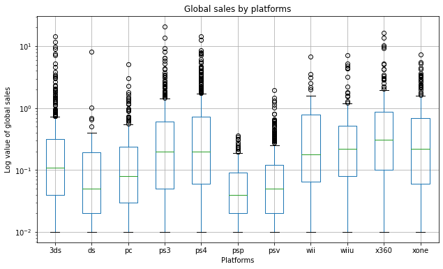

```python
games_new.boxplot('total_sales', by='platform', figsize=(10, 6))
plt.yscale("log")
plt.title('Global sales by platforms')
plt.suptitle("")
plt.ylabel('Log value of global sales')
plt.xlabel('Platforms')
plt.show()
```

All the sales distribution are right skewed, packed with outliers on the higher value end.

Having said the above, we need to bear in mind that, despite we only kept the data in the last 5 years, these figures can still be misleading, and the platforms on the decline might still have a decent average sales because of their previous sales performance.

**4.6 Impact of reviews on sales**

Given our previous analysis shows that **ps4** is potentially the rising star in the coming years, for this section examining the impact of reviews on sales, let's use ps4 as an example.

Let's first build a scatter plot to show the relationship between critic_score and total_sales, as well that between user_score and total_sales. Given that we know that there are missing values in these two columns, we will need to take care of them when plotting.

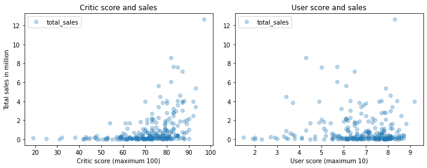

```python
fig, (ax1, ax2) = plt.subplots(1, 2, figsize=(10, 4))
games_new[(games_new['platform'] == "ps4")
          & (games_new['critic_score'].notnull())].plot(x='critic_score',
                                                        y='total_sales',
                                                        style='o',
                                                        alpha=0.3,
                                                        ax=ax1)
ax1.set_title('Critic score and sales')
ax1.set_ylabel('Total sales in million')
ax1.set_xlabel('Critic score (maximum 100)')

games_new[(games_new['platform'] == "ps4")
          & (games_new['user_score'].notnull())].plot(x='user_score',
                                                      y='total_sales',
                                                      style='o',
                                                      alpha=0.3,
                                                      ax=ax2)
ax2.set_title('User score and sales')
ax2.set_xlabel('User score (maximum 10)')

plt.tight_layout()
```

The above scatter plot shows a mild positive correlation between critic score and sales, and a very vague correlation between user score and sales.

```python
games_new.query('platform == "ps4"')[[
    'critic_score', 'user_score', 'total_sales'
]].corr()
```

|  | critic_score | user_score | total_sales |
| --- | --- | --- | --- |
| critic_score | 1.000000 | 0.557654 | 0.406568 |
| user_score | 0.557654 | 1.000000 | -0.031957 |
| total_sales | 0.406568 | -0.031957 | 1.000000 |

In the case of the ps4 platform, we can see that critic score and sales have a moderate positive correlation(0.407), whereas user score and sales have a close to 0 negative correlation. It is possible that users might tend to follow expert advice when purchasing games but users individual preferences and taste mght vary a lot and thus their review score of the games does not show clear correlation with game popularity.

**4.7 Sales of same games across different platforms**

Now we know ps4 might be a potential hit. It would be interesting to find out how the same games are performing in sales on other platforms. Let's find out.

```python
len(games_new.query('platform =="ps4"')['name'].unique())
```

```
392
```

```python
games_new.query('platform =="ps4"').groupby(
    'name')['total_sales'].sum().sort_values(ascending=False).head()
```

```
name
call of duty: black ops 3         14.63
grand theft auto v                12.62
fifa 16                            8.58
star wars battlefront (2015)       7.98
call of duty: advanced warfare     7.66
Name: total_sales, dtype: float64
```

The 5 top selling games are shown above. Let's pick the first one to compare sales across platforms.

```python
games_new.query('name == "call of duty: black ops 3"').groupby(
    'platform')['total_sales'].sum()
```

```
platform
pc       0.26
ps3      1.69
ps4     14.63
x360     1.70
xone     7.39
Name: total_sales, dtype: float64
```

It's interesting to see that the same game generated very different sales from different platforms. Taking the 'call of duty: black ops 3' game for example, ps4 is definitely the winner platform, followed by xone, leaving the other platforms far behind.

**4.8 Sales by genre**

In the analysis in this section, we are hoping to find out games of what genres are the most profitable!

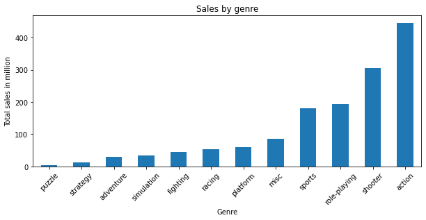

```python
games_new.groupby('genre')['total_sales'].sum().sort_values().plot(
    kind='bar', title="Sales by genre", figsize=(10, 4))
plt.xticks(rotation=45)
plt.xlabel("Genre")
plt.ylabel('Total sales in million')
plt.show()
```

However, we need to keep in mind that the sales calculated in the above graph are global sales. We might expect for different regions the popularity of the genres might differ. This is what we are going to look at next in the next section.

### Part 4 summary

We also came to learn what game platforms were leading in sales, and how that might change over the years. Given what seems to be the typical life span of platforms, 10 years, we further subset the data to include only those in the last 5 years for further analysis.

The analysis of the reduced dataset reveals two strong candidates for potential sales growth, **ps4** and **xone**, which should be the focus for promotion by the store.

It is also interesting to know that the expert reviews did show a mild positive correlation with sales, and the sales of the same game can vary greatly across platforms.

### Part 5: Games and regions

**5.1 Top 5 platforms in each region**

First, let's build a user profile by region to find out the market share by platform.

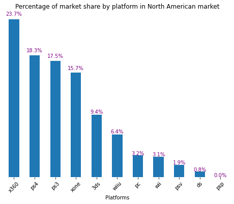

```python
y = games_new.groupby('platform')['na_sales'].sum().sort_values(
    ascending=False) / games_new.groupby('platform')['na_sales'].sum().sum()
ax = y.plot(kind='bar', figsize=(8, 6))
plt.title("Percentage of market share by platform in North American market",
          fontsize=12)

plt.xticks(fontsize=10, rotation=45)
for spine in plt.gca().spines.values():
    spine.set_visible(False)
plt.yticks([])
plt.xlabel("Platforms")

for p in ax.patches:
    width = p.get_width()
    height = p.get_height()
    x, y = p.get_xy()
    ax.annotate(f'{height:.1%}', (x + width / 2, y + height * 1.025),
                ha='center',
                color='purple')
plt.show()
```

The top five platforms in North America, as shown above, are x360, ps4, ps3, xone, and 3ds, occupying over 80% of the market!

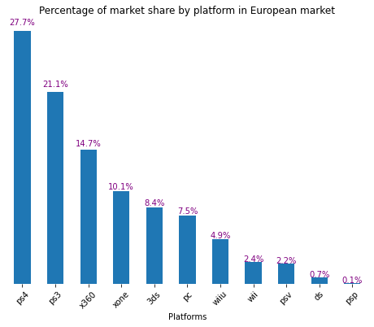

```python
y = games_new.groupby('platform')['eu_sales'].sum().sort_values(
    ascending=False) / games_new.groupby('platform')['eu_sales'].sum().sum()
ax = y.plot(kind='bar', figsize=(8, 6))
plt.title("Percentage of market share by platform in European market",
          fontsize=12)

plt.xticks(fontsize=10, rotation=45)
for spine in plt.gca().spines.values():
    spine.set_visible(False)
plt.yticks([])
plt.xlabel("Platforms")

for p in ax.patches:
    width = p.get_width()
    height = p.get_height()
    x, y = p.get_xy()
    ax.annotate(f'{height:.1%}', (x + width / 2, y + height * 1.025),
                ha='center',
                color='purple')
plt.show()
```

The top five platforms in Europe, as shown above, are ps4, ps3, x360, xone, and 3ds, also representing over 80% of the market share.

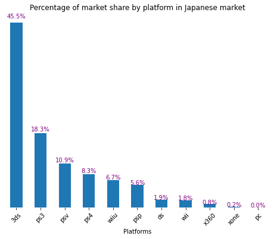

```python
y = games_new.groupby('platform')['jp_sales'].sum().sort_values(
    ascending=False) / games_new.groupby('platform')['jp_sales'].sum().sum()
ax = y.plot(kind='bar', figsize=(8, 6))
plt.title("Percentage of market share by platform in Japanese market",
          fontsize=12)

plt.xticks(fontsize=10, rotation=45)
for spine in plt.gca().spines.values():
    spine.set_visible(False)
plt.yticks([])
plt.xlabel("Platforms")

for p in ax.patches:
    width = p.get_width()
    height = p.get_height()
    x, y = p.get_xy()
    ax.annotate(f'{height:.1%}', (x + width / 2, y + height * 1.025),
                ha='center',
                color='purple')
plt.show()
```

It's fascinating to see how 3ds dominated the Japanese market in the five years leading to 2016! It alone takes almost half of the market. Following 3ds are ps3, psv, ps4, and wiiu.

It's intereting to see that while the top 5 platforms are the same for North America and Europe, only differing in order, the japanese market is quite different, with **3ds** clearly dominating the market share. It would be interesting to find out why this is the case. Is it because of the kind of the games released on 3ds, or the result of marketing promotion? However, this is beyond the scope of this report. We will move on.

**5.2 Top 5 genres in each region**

Let's have a change and use numbers instead of charts for this analysis. We will calcualte the percentage of market share for the top five genres in each region.

```python
games_new.groupby('genre')['na_sales'].sum().sort_values(ascending=False).head(
) / games_new.groupby('genre')['na_sales'].sum().sum()
```

```
genre
action          0.303641
shooter         0.244042
sports          0.137418
role-playing    0.107871
misc            0.064369
Name: na_sales, dtype: float64
```

```python
games_new.groupby('genre')['eu_sales'].sum().sort_values(ascending=False).head(
) / games_new.groupby('genre')['eu_sales'].sum().sum()
```

```
genre
action          0.317569
shooter         0.222849
sports          0.135689
role-playing    0.095310
racing          0.053596
Name: eu_sales, dtype: float64
```

```python
games_new.groupby('genre')['jp_sales'].sum().sort_values(ascending=False).head(
) / games_new.groupby('genre')['jp_sales'].sum().sum()
```

```
genre
role-playing    0.339384
action          0.273831
misc            0.067939
simulation      0.053988
fighting        0.048958
Name: jp_sales, dtype: float64
```

It's interesting, isn't it? Role playing is the biggest player in the Japanese market, representing over 30% of the market share. Sports and shooter, which are both very popular genres in North America and Europe, didn't even make to the top five in Japan!

**5.3 ESRB ratings and sales in each region**

Does ESRB ratings affect sales? How does that differ across regions. Let's find out.

```python
games_new.groupby('rating')['na_sales'].sum().sort_values(
    ascending=False).head() / games_new.groupby(
        'rating')['na_sales'].sum().sum()
```

```
rating
M            0.390477
E            0.192769
undefined    0.174128
E10+         0.131350
T            0.111276
Name: na_sales, dtype: float64
```

```python
games_new.groupby('rating')['eu_sales'].sum().sort_values(
    ascending=False).head() / games_new.groupby(
        'rating')['eu_sales'].sum().sum()
```

```
rating
M            0.381869
E            0.221984
undefined    0.179701
E10+         0.112436
T            0.104010
Name: eu_sales, dtype: float64
```

```python
games_new.groupby('rating')['jp_sales'].sum().sort_values(
    ascending=False).head() / games_new.groupby(
        'rating')['jp_sales'].sum().sum()
```

```
rating
undefined    0.565709
E            0.146925
T            0.134945
M            0.109947
E10+         0.042475
Name: jp_sales, dtype: float64
```

In ESRB rating system, M refers to mature audience, E refers to everython, T refers to teenager. Previously, we replaced the missing values in this column with "undefined".

From the results above, we can see that. while in North America and Europe, M and E top the sales, in Japan, it's the 'undefined' that accounts for over 50% of the sales. That's very significant!

A quick search of ESRB rating information online reveals that ESRB doesn't rate certain games. Is it possible that these are the kind of games that were popular in Japan? It would be interesting to find out!

In conclusion, North American and European market show great similarity in terms of what platforms and genres are popular, as well as what rating games are most profitable. The japanese market is quite different, showing a different preference in all three aspects. This is interesting information when it comes to promoting games in different regions.

### Part 6: Hypothesis testing

In this section, we will test the following two hypotheses:

- Average user ratings of the Xbox One and PC platforms are the same.
- Average user ratings for the Action and Sports genres are different.

Both are two sided test, and the alpha threshold value is set as 0.05, following what is typically used in hypothesis testing.

**6.1 Hypothesis test 1**

The null hypothesis for this test is that the average user score of the xone and pc platforms are the same.

The alternative hypothesis is that they are different. We will use T test.

First, let's creat two datasets, one for Xbox One, and the other for PC platform.

```python
xone = games_new.query("platform == 'xone'")
pc = games_new.query("platform == 'pc'")
```

It needs to be noted user rating (user_score) has missing values. Let's check how many are they.

```python
xone['user_score'].isna().sum()/len(xone)
```

```
0.2631578947368421
```

```python
pc['user_score'].isna().sum()/len(pc)
```

```
0.17254901960784313
```

We will need to exclude those missing values when performing the hypothesis testing. Let's create two series containing only user_score values for each platform.

```python
pc_user_score = pc[pc['user_score'].notna()]['user_score']
xone_user_score = xone[xone['user_score'].notna()]['user_score']
```

Next, let's look at the summary statistics of the two sets.

```python
pc_user_score.describe()
```

```
count    211.000000
mean       6.445498
std        1.657455
min        1.400000
25%        5.500000
50%        6.800000
75%        7.700000
max        9.300000
Name: user_score, dtype: float64
```

```python
xone_user_score.describe()
```

```
count    182.000000
mean       6.521429
std        1.380941
min        1.600000
25%        5.800000
50%        6.800000
75%        7.500000
max        9.200000
Name: user_score, dtype: float64
```

Before we perform the t test to compare the means of the user_score between two platforms, we need to find out if they are from a normal distribution.

```python
st.shapiro(pc_user_score)
```

```
ShapiroResult(statistic=0.9391269683837891, pvalue=1.0094110081126928e-07)
```

```python
st.shapiro(xone_user_score)
```

```
ShapiroResult(statistic=0.955055296421051, pvalue=1.524856543255737e-05)
```

Both have pvalue a lot smaller than 0.05, which indicates that the values are not from a normal distribution. Therefore, to find out if the two sets of score have similar variance, we will use the levene test.

```python
st.levene(xone_user_score, pc_user_score, center = 'mean')
```

```
LeveneResult(statistic=8.08494594662182, pvalue=0.004697715245950616)
```

Pvalue from teh Levene test is smaller than 0.05, which indicates that the two sets of values have different variance. We will set the equal_var as False for the t test below.

```python
st.ttest_ind(xone_user_score, pc_user_score, equal_var=False).pvalue
```

```
0.6206366351489678
```

Pvalue from the T test is higher than our significance threshold value, 0.05, therefore we can not reject the null hypothesis, that the average ratings of the xone and pc platform are the same.

**6.2 Hypothesis test 2**

For this test, our null hypothesis is: average user ratings for the Action and Sports genres are the same.

Our alternative hypothesis is, they are different.

First, let's subset the data.

```python
action = games_new.query("genre == 'action'")
action_user_score = action[action['user_score'].notna()]['user_score']

sports = games_new.query("genre == 'sports'")
sports_user_score = sports[sports['user_score'].notna()]['user_score']
```

```python
action_user_score.describe()
```

```
count    531.000000
mean       6.834275
std        1.371830
min        1.600000
25%        6.250000
50%        7.200000
75%        7.800000
max        9.100000
Name: user_score, dtype: float64
```

```python
sports_user_score.describe()
```

```
count    195.000000
mean       5.455897
std        1.738646
min        0.200000
25%        4.300000
50%        5.700000
75%        6.800000
max        8.800000
Name: user_score, dtype: float64
```

First, we need to do a shapiro test to see if the two sets of scores are from a normal distribution.

```python
st.shapiro(action_user_score)
```

```
ShapiroResult(statistic=0.9130260944366455, pvalue=6.793095049138632e-17)
```

```python
st.shapiro(sports_user_score)
```

```
ShapiroResult(statistic=0.9690107107162476, pvalue=0.0002625079359859228)
```

Neither is from a normal distribution. So we will use levene test again to check on variance.

```python
st.levene(action_user_score, sports_user_score, center = 'mean')
```

```
LeveneResult(statistic=21.612045493018282, pvalue=3.966250544508889e-06)
```

The test above results in a very small pvalue, therefore we will set equal_var as False.

```python
st.ttest_ind(action_user_score, sports_user_score, equal_var=False).pvalue
```

```
2.337200239591976e-20
```

The pvalue from the test is a lot smaller than alpha, 0.05, therefore we can reject the null hypothesis and conclude that the average user ratings for action and sports genre games are different!

In conclusion, using alpha 0.05, we can conclude that average user ratings of the Xbox One and PC platforms are the same, but average user ratings for the Action and Sports genres are different.

### Part 7: Findings and conclusions

This report has presented the analysis of the video games sales data from the online store Ice, from 1980 to 2016.

The goal of the analysis was to identify patterns that determine a game's success,which will then allow the store owners to spot potential sales winners and plan advertising campaigns.

We found out that the typical lifespan for a game platform was approximately 10 years. During this time, the platform would reach the peak of its popularity, as measured in sales, when it was 4 or 5 years old, after which the sales started to decline, until finally the platform was replaced by newer platforms and disappearred from the market.

Based on this information, the store owner should focus the promotion on platforms that are perhaps 3 or 4 years old and still showing a rising trend in sales. Our study shows that **ps4** and **xone** are good candidate for market promotion.

However, knowing which platforms to promote is only half of the game. The owner should also try to get more positive expert reviews for the platforms and games they are promoting because our analysis shows a moderate positive correlation between expert review and sales.

Furthermore, store owner should also be aware of the region differences in their preference in platform, genre, and ESRB ratings. The Japanese market in particular shows a different preference from the North American and European market.

The marketing team will need to adjust their focus and strategy when promoting video games in different regions. For example, while shooter and sports games might do well in sales in North America and Europe, they are likely to perform poorly in Japan. Instead, games of role playing genre with even no ESRB ratings might be a safe bet for the Japanese market.

The analysis also leave us a couple of issues that might worth further investigation. For example, why are there so many missing values in critic_score, user_score, and ESRB ratings? Why games with missing ESRB ratings sell so well in Japan?